# Předmět: Bayesiánská analýza (MPE_BAAN)

Třetí úkol, příklad 1 (9.16 - 9.20) - skupina 13

2026-07-14

## Exercise 9.16: Penguins - Prior Model

*Zdroj: [Exercise 9.16](https://www.bayesrulesbook.com/chapter-9#exercises-8)*

> Dataset `penguins_bayes` v balíčku bayesrules obsahuje údaje o 344 tučniakoch. V nasledujúcich cvičeniach použijete tieto dáta na modelovanie dĺžky plutiev tučniakov v mm ($Y$) na základe dĺžky ich zobákov v mm ($X$). Máme všeobecnú predstavu, že priemerný tučniak má plutvy dlhé niekde medzi 150 mm a 250 mm. Okrem toho nemáme silné predpoklady o vzťahu medzi dĺžkou plutvy a dĺžkou zobáka, a preto pre ostatné parametre využijeme málo informatívne apriórne rozdelenia (weakly informative priors).
> 1. Simulujte apriórny model normálnej regresie pre `flipper_length_mm` na základe `bill_length_mm` pomocou 4 reťazcov (chains) s 10 000 iteráciami pre každý. NÁPOVEDA: Môžete použiť rovnakú syntax `stan_glm()`, akú by ste použili na simuláciu posteriórneho modelu, ale pridajte argument `prior_PD = TRUE`.
> 2. Skontrolujte výstup `prior_summary()` a na jeho základe rozpíšte kompletnú štruktúru vášho modelu normálnej regresie (9.6).
> 3. Vykreslite 100 apriórne možných modelových priamok ($\beta_0 + \beta_1 X$) a 4 datasety simulované z apriórneho modelu.
> 4. Zhrňte vaše málo informatívne apriórne chápanie vzťahu medzi dĺžkou plutvy a dĺžkou zobáka.

### a. Apriórny model

**Dáta v apriórnom modeli**

```
##  flipper_length_mm bill_length_mm
##  Min.   :172.0     Min.   :32.10
##  1st Qu.:190.0     1st Qu.:39.23
##  Median :197.0     Median :44.45
##  Mean   :200.9     Mean   :43.92
##  3rd Qu.:213.0     3rd Qu.:48.50
##  Max.   :231.0     Max.   :59.60
##  NA's   :2         NA's   :2
```

**Nastavenie prior modelu:**

- V zadaní je uvedené, že použijeme málo informatívne apriórne modely, keďže máme málo predpokladov o dátach. Preto nastavíme parameter `autoscale` v metóde pre parametre $\beta_1$ a $\sigma$ na `TRUE`. `Rstanarm` tak automaticky upraví smerodajnú odchýlku pre prior podľa dát.
- Taktiež nemáme predpoklad o smere závislosti, či je kladná alebo záporná. Preto nastavíme strednú hodnotu prioru pre koeficient $\beta_1$ na nulu.

**ZADANÉ HYPERPARAMETRE:**

- Intercept: $m_0 = 200$, $s_0 = 25$ (z intervalu 150 - 250mm)
- Slope: $m_1 = 0$, $s_1$ - weakly informative (autoscale)
- Sigma: $l$ - weakly informative (autoscale)

**APRIÓRNY MODEL:**

$$\begin{align}
\text{Data: } \quad Y_i | \beta_0, \beta_1, \sigma
&\stackrel{ind}{\sim} N(\mu_i, \sigma^2)
\quad\text{kde} \quad \mu_i = \beta_0 + \beta_1 X_i \\
\text{Priors: } \quad \beta_{0c} &\sim N(m_0 = 200, s_0^2 = 25^2)
\quad \text{informatívny} \\
\beta_1 &\sim N(m_1 = 0, s_1^2)
\quad \text{málo informatívny} \\
\sigma &\sim \text{Exp}(l)
\quad \text{málo informatívny}
\end{align}$$

### b. Štruktúra modelu

- stredná hodnota $m_0$ a smerodajná odchýlka $s_0$ pre $\beta_0$ sa nezmenili, N(200, 25)
- stredná hodnota $m_1$ pre $\beta_1$ sa nezmenila, je stále 0
- smerodajná odchýlka $s_1$ pre $\beta_1$ sa prepočítala: z defaultnej hodnoty 2.5 na 6.44
- parameter $\sigma$, ako vstup $1/\sigma$ pre exponenciálne rozdelenie sa prepočítal z 1 na 14.062

**APRIÓRNY MODEL** sa aktualizoval:

$$\begin{align}
\text{Data: } \quad Y_i | \beta_0, \beta_1, \sigma
&\stackrel{ind}{\sim} N(\mu_i, \sigma^2)
\quad\text{kde} \quad \mu_i = \beta_0 + \beta_1 X_i \\
\text{Priors: } \quad \beta_{0c} &\sim N(m_0 = 200, s_0^2 = 25^2)\\
\beta_1 &\sim N(m_1 = 0, s_1^2 = 6.44) \\
\sigma &\sim \text{Exp}(l = 1 / \sigma = 0.07)
\end{align}$$

### c. Vizualizácia apriórnych modelov

**Graf: 100 apriórnych modelových čiar**

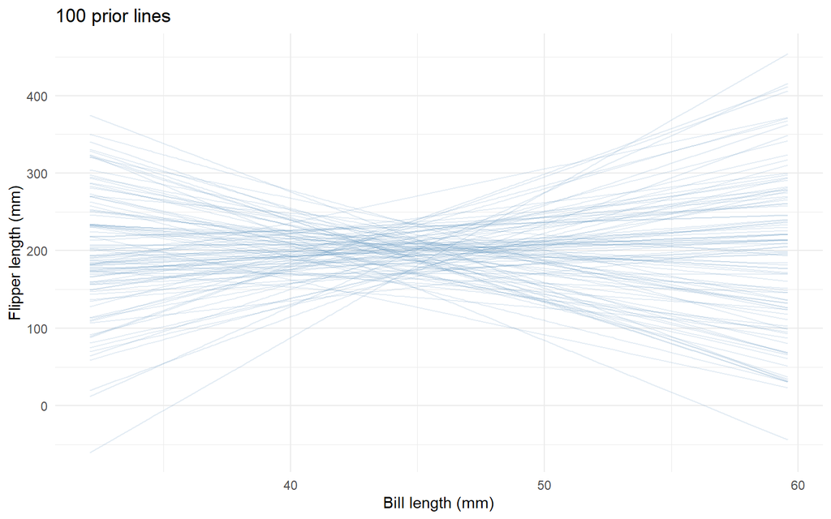

**Datasety - možné scénare:** - každý dataset predstavuje 342 simulovaných hodnôt **flipper_length** pre každého tučniaka vytvorených podľa našej predstavy pred skutočným videním dát - 4 trojice náhodných hodnôt pre hyperparametre z MCMC

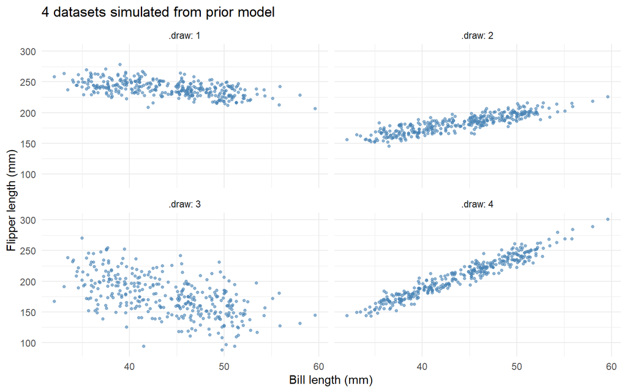

### d. Sumarizácia apriórneho pochopenia

Prior model odráža našu neistotu pred preskúmaním dát:

**Vieme:**

- Typický tučniak má plutvy cca 200mm (150-250mm)

**Nevieme:**

- Či existuje vzťah medzi zobákom a plutvami
- Ak áno, či je pozitívny alebo negatívny a ako silný

**Z prvého grafu 100 priamok:**

- 100 priamok rôznej šikmosti: aj rastúce, aj klesajúce
- vačšina čiar prechádza okolo 200 mm pri stredných hodnotách zobáka
- široký rozptyl –> veľká neistota

**Z grafu - 4 simulované datasety**

- 4 simulované datasety ukazujú úplne odlišné scenáre
- Prior je *weakly informative* - nezahŕňa príliš veľké, ani príliš malé nezmysluplné hodnoty, ale sú možné rôzne vzťahy

## Exercise 9.17: Penguins - Data Exploration

> 1. Plot and discuss the observed relationship between `flipper_length_mm` and `bill_length_mm` among the 344 sampled penguins.
> 2. Does simple Normal regression seem to be a reasonable approach to modeling this relationship? Explain.

### a. Vizualizácia dát

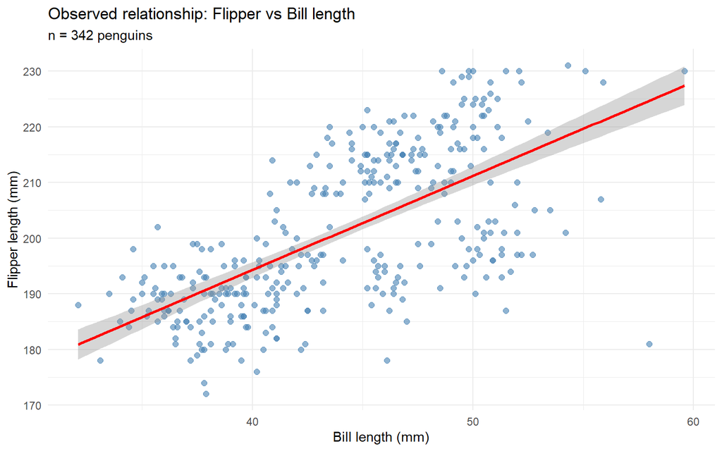

Medzi 342 tučniakmi vidíme pozitívny lineárny vzťah. Korelačný koeficient je **r = 0.656**. Teda `bill length` vysvetľuje približne **43.1%** variability v dĺžke plutvy.

### b. Vhodnosť normálnej regresie

**Kontrola predpokladov:**

1. **Linearita:** Vzťah vyzerá lineárne, nie je viditeľné nejaké zakrivenie.
2. **Normalita a homoskedasticita:** Rozptyl bodov okolo čiary vyzerá približne konštantný.
3. **Nezávislosť:** Každý tučniak predstavuje samostatné pozorovanie.

Jednoduchá normálna regresia je vhodná.

## Exercise 9.18: Penguins - Posterior Analysis

> 1. Use `stan_glm()` to simulate the Normal regression posterior model. HINT: You can either do this from scratch or `update()` your prior simulation from Exercise 9.16 using `prior_PD = FALSE`.
> 2. Plot 100 posterior model lines for the relationship between flipper and bill length.
> 3. Provide a `tidy()` summary of your posterior model, including 90% credible intervals.
> 4. Interpret the 90% posterior credible interval for the `bill_length_mm` coefficient, $\beta_1$.
> 5. Do we have ample posterior evidence that penguins with longer bills tend to have longer flippers? Explain.

### a. Posteriorna simulácia

### b. Graf 100 posteriórnych priamok

Porovnanie priórnych a posteriórnych priamok

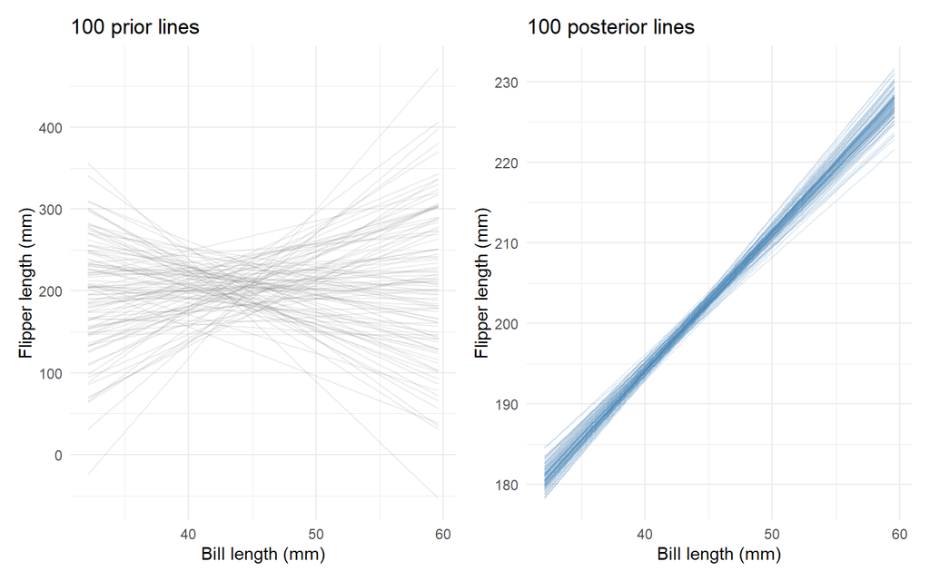

### c. Tidy summary s 90% CI

Posterior summary with 90% credible intervals

| Parameter | Median | 90% CI Lower | 90% CI Upper |
| --- | --- | --- | --- |
| β₀ (Intercept) | 126.74 | 118.99 | 134.37 |
| β₁ (bill_length_mm) | 1.69 | 1.52 | 1.86 |
| σ (sigma) | 10.64 | 10.01 | 11.34 |
| mean_PPD | 200.90 | 199.57 | 202.25 |

Posteriorne mediány parametrov:

- **Intercept ($\beta_0$):** 126.74 mm  
  90% CI: [118.99, 134.37]
- **Slope ($\beta_1$):** 1.69 mm  
  90% CI: [1.52, 1.86]
- **Sigma (σ):** 10.64 mm  
  90% CI: [10.01, 11.34]

### d. Interpretácia 90% posteriórneho kredibilného intervalu pre $\beta_1$

Za každý **1mm nárast v dĺžke zobáka**, dĺžka plutiev v priemere **narastie o 1.69 mm**.

- S 90% pravdepodobnosťou je skutočná hodnota $\beta_1$ medzi 1.52 a 1.86 mm. To znamená, že sme si na 90% istí, že za každý 1mm dlhší zobák sú plutvy dlhšie o približne 1.52 až 1.86 mm.

### e. Preukázanie posteriórneho vzťahu

- Celý interval je **nad nulou** -> čiže silná evidencia pre pozitívny vzťah
- To možno vidieť aj na grafoch 100 priamok, všetky majú pozitívny sklon -> žiadna posteriórna vzorka nenaznačuje negatívny vzťah

## Exercise 9.19: Penguins - Posterior Prediction

> Suppose we meet Pablo the penguin whose bill is 51mm long.
> 1. Without using the `posterior_predict()` shortcut function, simulate the posterior model for the typical flipper length among penguins with 51mm bills as well as the posterior predictive model for Pablo’s flipper length.
> 2. Construct, discuss, and compare density plot visualizations for the two separate posterior models in part a.
> 3. Calculate and interpret an 80% posterior prediction interval for Pablo’s flipper length.
> 4. Would the 80% credible interval for the typical flipper length among all penguins with 51mm bills be wider or narrower? Explain.
> 5. Use `posterior_predict()` to confirm your results to parts b and c.

### a. Manuálna simulácia predikcie

Odhadnúť dĺžku plutvy, ak poznáme, že bill je 51 mm

**Posteriórny model**:
$$\begin{equation}
Y_i | \beta_0, \beta_1, \sigma \stackrel{ind}{\sim} N\left(\mu_i,
\sigma^2\right) \;\; \text{ kde } \;\; \mu_i = \beta_0 + \beta_1X_i \\
\end{equation}$$

### b. Porovnanie posteriorných modelov

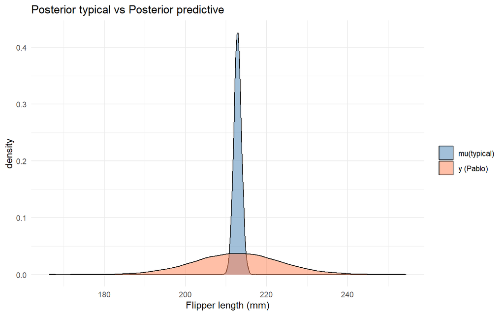

### c. Prediction interval pre Pabla

**80% Posterior predikčný interval**: [199.2, 226.3] mm

S 80% pravdepodobnosťou má Pablo plutvy dlhé medzi 199.2 a 226.3 mm.

### d. Porovnanie šírok intervalov

Kredibilný interval pre typickú dĺžku plutvy je užší, lebo kredibilný interval zahŕňa len neistotu v hodnotách regresných parametrov. Predikčný interval zahŕňa aj individuálnu variabilitu konkrétneho jedinca (Pabla) od typickej hodnoty. Odhad priemeru je v užšom intervale ako odhad jedinca.

- **80% kredibilný interval**: [211.7, 214.1] mm

Typická hodnota je vo vyznačenom intervale:

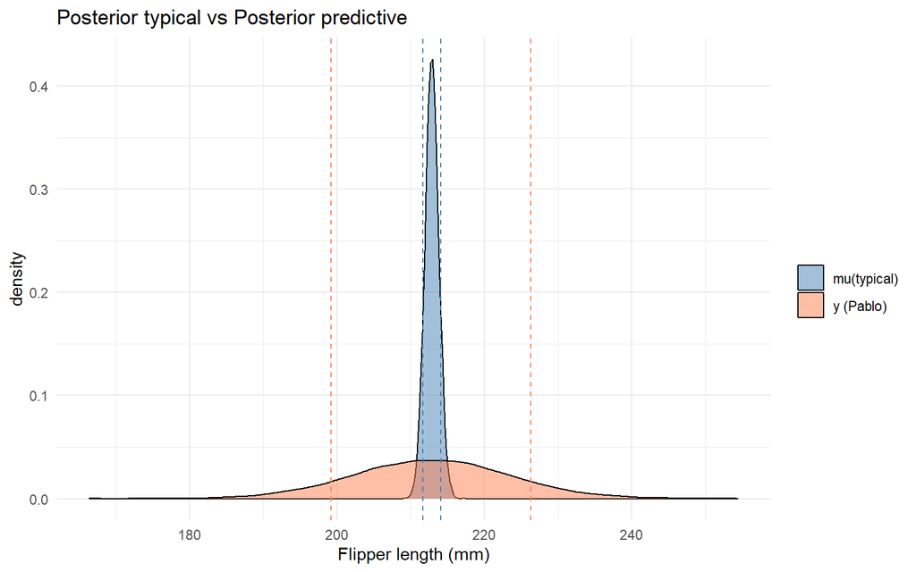

### e. Overenie pomocou `posterior_predict()`

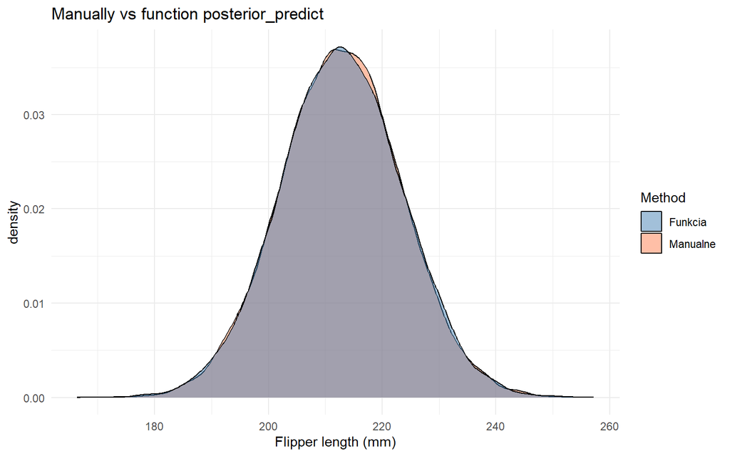

## Exercise 9.20: Penguins - Body Mass Model

> Instead of bill length, consider the Normal regression model of penguin flipper lengths ($Y$) by body mass in grams ($X$).

> a.Based on their study of penguins in other regions, suppose that researchers are quite certain about the relationship between flipper length and body mass, prior to seeing any data: $\beta_1 \sim N(0.01, 0.002^2)$. Describe their prior understanding.
> 2. Plot and discuss the observed relationship between `flipper_length_mm` and `body_mass_g` among the 344 sampled penguins.
> 3. In a simple Normal regression model of flipper length $Y$ by one predictor $X$, do you think that the $\sigma$ parameter is bigger when $X$ = bill length or when $X$ = body mass? Explain your reasoning and provide some evidence from the information you already have.
> 4. Use `stan_glm()` to simulate the Normal regression posterior model of flipper length by body mass using the researchers’ prior for $\beta_1$ and weakly informative priors for $\beta_{0c}$ and $\sigma$. Do so with 4 chains run for 10000 iterations each.
> 5. Plot the posterior model of the $\beta_1$ `body_mass_g` coefficient. Use this to describe the researchers’ posterior understanding of the relationship between flippers and mass and how, if at all, this evolved from their prior understanding.

### a. Apriórne pochopenie vzťahu

Výskumníci prepodkladajú, že $\beta_1$ ≈ 0.01 mm/g. To znamená:

- Za každý **1g** nárastu hmotnosti → plutvy dlhšie o **0.01 ± 2 * 0.002 mm**
- Za každý **1kg** -> plutvy dlhšie o **10 ± 2 * 2 mm**

95% prior interval: 0.01 ± 2 * 0.002 = [0.006, 0.014]

**ZADANÉ HYPERPARAMETRE:**

- Intercept: $m_0 = 200$, $s_0 = 25$ (z intervalu 150 - 250mm)
- Slope: $m_1 = 0.01$, $s_1 = 0.002$ - informative
- Sigma: $l$ - weakly informative (autoscale)

**APRIÓRNY MODEL:**

$$\begin{align}
\text{Data: } \quad Y_i | \beta_0, \beta_1, \sigma
&\stackrel{ind}{\sim} N(\mu_i, \sigma^2)
\quad\text{kde} \quad \mu_i = \beta_0 + \beta_1 X_i \\
\text{Priors: } \quad \beta_{0c} &\sim N(m_0 = 200, s_0^2 = 25^2)
\quad \text{informatívny} \\
\beta_1 &\sim N(m_1 = 0.01, s_1^2 = 0.002^2)
\quad \text{informatívny} \\
\sigma &\sim \text{Exp}(l)
\quad \text{málo informatívny}
\end{align}$$

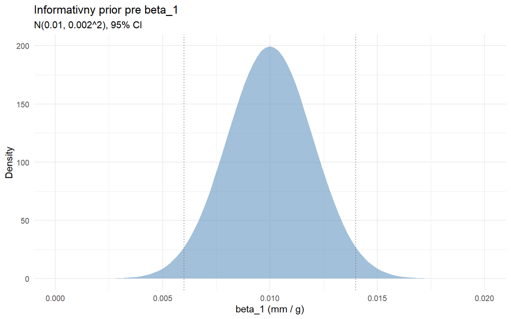

### b. Vizualizácia vzťahu flipper length a body mass

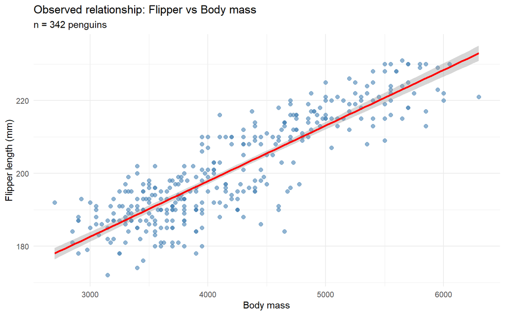

Medzi 342 tučniakmi vidíme pozitívny lineárny vzťah. Korelačný koeficient je **r = 0.871**. Teda `body_mass_g` vysvetľuje približne **75.9%** variability dĺžky plutvy.

### c. Porovnanie $\sigma$ pre rôzne prediktory

$\sigma$ meria rozptyl okolo priamky: $Y_i \sim N(\beta_0 + \beta_1 X_i, \sigma^2)$

$\sigma$ je menšia pre `body mass` model ako pre `bill length` model.

Keď porovnáme dĺžku plutvy ako závislú premennú od jedného prediktora v jednoduchej normálnej regresii:

- `body mass` tesnejšie koreluje s dĺžkou plutvy ako `dĺžka zobáka`
- na grafe vidno, že body sú tu bližšie ku regresnej priamke
- teda rozptyl od typickej hodnoty je menší

Korelácie:

- Flipper vs Bill length: r = 0.656
- Flipper vs Body mass: r = 0.871
- `Body mass` má silnejšiu koreláciu (0.871 > 0.656)

#### d. Posteriorna simulácia s informatívnym priorom

- namiesto `weakly informative` prioru použijeme prior výskumníkov o $\beta_1$ koeficiente

Posterior summary with 90% credible intervals

| Parameter | Median | 90% CI Lower | 90% CI Upper |
| --- | --- | --- | --- |
| β₀ (Intercept) | 137.879 | 134.669 | 141.063 |
| β₁ (body_mass_g) | 0.015 | 0.014 | 0.016 |
| σ (sigma) | 6.927 | 6.517 | 7.385 |
| mean_PPD | 200.905 | 200.030 | 201.777 |

#### e. Evolúcia pochopenia vzťahu

- porovnanie pochopenia regresného koeficientu na začiatku v priori a následne v posteriórnom modeli.

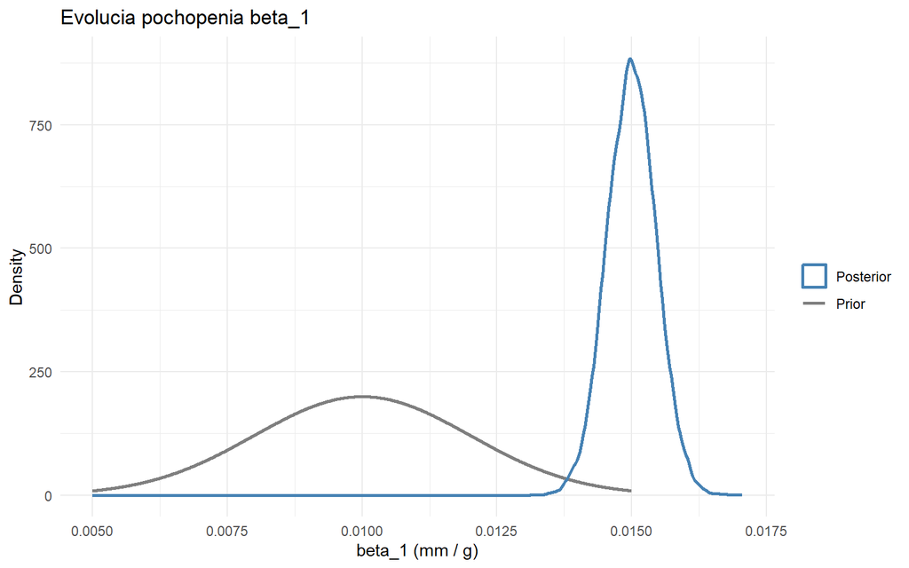

Evolúcia pochopenia:

Prior: $\beta_1$ = 0.01 (výskumníci očakávali) Posterior: $\beta_1$ ≈ 0.015

Posterior je vyšší ako prior.